# Report 5

## Computational Neuroscience

## Computer Assignment 5

### 610098014

```python
from PIL import Image
import numpy as np
import torch
import matplotlib.pyplot as plt
```

```python
from cnsproject.encoding.encoders import Time2FirstSpikeEncoder, PoissonEncoder, PositionEncoder
from cnsproject.plotting.plotting import plotting
```

## Walkthrough

In this part we first read the image. transform it into the grayscale form and reduce its resolution to 200*200 px and in the end transform it to a tensor.

[figure not shown]

```python
im = Image.open("./img.jpg").convert('L')
im = im.resize((200,200),Image.ANTIALIAS)
data = torch.from_numpy(np.asarray(im))
plt.imshow(im)
plt.show()
```

In this part we will make a encoder and encode the input tensor.

```python
time = 20
encoder = Time2FirstSpikeEncoder(time = time)
I = encoder(data)
fi = torch.flatten(I, start_dim=1)
```

Then we will plot a roaster plot which shows the neuron's spikes in each unit of time.

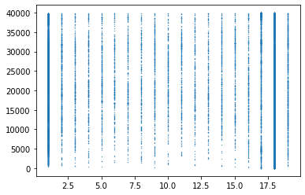

```python
sf = np.flipud(fi.T)
args = np.argwhere(sf)
plt.scatter(args.T[1,:], args.T[0,:], s=0.1)
plt.show()
```

In the end, we will decode the encoded matrix and then plot it to see the original picture.

[figure not shown]

```python
x = encoder.decode(fi.numpy(), (200,200))
plt.imshow(x)
plt.show()
```

## Time to First Spike Encoder

Like the previous part, in this part we are looking forward to check the Time2FirstSpikeEncoder.

The left images are before(up) the encoding and after(down) the decoding. The right plot is the encoded pattern.

```
No handles with labels found to put in legend.
```

[figure not shown]

```python
time = 10
encoder = Time2FirstSpikeEncoder(time = time)
I = encoder(data)
fi = torch.flatten(I, start_dim=1)
x = encoder.decode(fi.numpy(), (200,200))
plot = plotting()
plot.plot_encoding_decoding(data,fi,x)
plot.show()
```

As we can see in the previous cell, it doesn't have all the details of the main image but on the other hand it doen't have any noise. For improving the output we can increase the time for encoding.

```
No handles with labels found to put in legend.
```

[figure not shown]

```python
time = 20
encoder = Time2FirstSpikeEncoder(time = time)
I = encoder(data)
fi = torch.flatten(I, start_dim=1)
x = encoder.decode(fi.numpy(), (200,200))
plot = plotting()
plot.plot_encoding_decoding(data,fi,x)
plot.show()
```

## Poisson Encoder

In this part we are looking forward to check the PoissonEncoder.

```
No handles with labels found to put in legend.
```

[figure not shown]

```python
time = 20
encoder = PoissonEncoder(time = time, r = 10)
I = encoder(data)
fi = torch.flatten(I, start_dim=1)
x = encoder.decode(fi.numpy(), (200,200))
plot = plotting()
plot.plot_encoding_decoding(data,fi,x)
plot.show()
```

As we can see in the previous cell, there is some noise in the decoded image but on the other hand it shows the details better. For improving the output we can increase the r(scale rate) for encoding.

```
No handles with labels found to put in legend.
```

[figure not shown]

```python
time = 20
encoder = PoissonEncoder(time = time, r = 20)
I = encoder(data)
fi = torch.flatten(I, start_dim=1)
x = encoder.decode(fi.numpy(), (200,200))
plot = plotting()
plot.plot_encoding_decoding(data,fi,x)
plot.show()
```

## Representing Number

In this part we are looking forward to check the PositionEncoder.

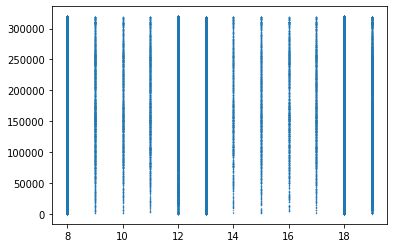

```python
time = 20
neuron_numbers = 8
neuron_range_mean = np.arange(1,neuron_numbers+1)
neuron_range_std = [1]*neuron_numbers
encoder = PositionEncoder(time = time, neuron_numbers=neuron_numbers,
    neuron_range_mean=neuron_range_mean, neuron_range_std=neuron_range_std)
I = encoder(data)
fi = torch.flatten(I, start_dim=1)
sf = np.flipud(fi.T)
args = np.argwhere(sf)
plt.scatter(args.T[1,:], args.T[0,:], s=0.1)
plt.show()
```

## For another image

### Time2First

```
No handles with labels found to put in legend.
```

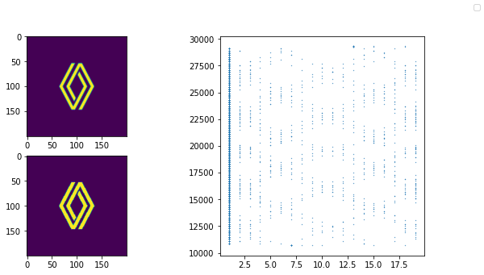

```python
im = Image.open("./img2.jpg").convert('L')
im = im.resize((200,200),Image.ANTIALIAS)
data = torch.from_numpy(np.asarray(im))
time = 20
encoder = Time2FirstSpikeEncoder(time = time)
I = encoder(data)
fi = torch.flatten(I, start_dim=1)
x = encoder.decode(fi.numpy(), (200,200))
plot = plotting()
plot.plot_encoding_decoding(data,fi,x)
plot.show()
```

### Poisson

```
No handles with labels found to put in legend.
```

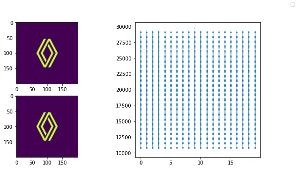

```python
time = 20
encoder = PoissonEncoder(time = time, r=20)
I = encoder(data)
fi = torch.flatten(I, start_dim=1)
x = encoder.decode(fi.numpy(), (200,200))
plot = plotting()
plot.plot_encoding_decoding(data,fi,x)
plot.show()
```

### Numbers

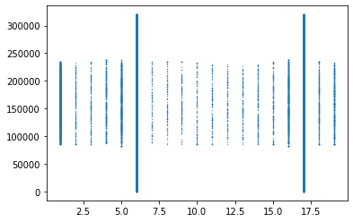

```python
time = 20
neuron_numbers = 8
neuron_range_mean = np.arange(1,neuron_numbers+1)
neuron_range_std = [1]*neuron_numbers
encoder = PositionEncoder(time = time, neuron_numbers=neuron_numbers,
    neuron_range_mean=neuron_range_mean, neuron_range_std=neuron_range_std)
I = encoder(data)
fi = torch.flatten(I, start_dim=1)
sf = np.flipud(fi.T)
args = np.argwhere(sf)
plt.scatter(args.T[1,:], args.T[0,:], s=0.1)
plt.show()
```